# 完整FM17的第三赛果：场景、漏保与尾部前后

本报告研究26098、26101、26102三期 **FM-1.7.0最终概率**的第三名实际发生，即Top2未覆盖。不是比分第三档、也不是原生λ单独预测；对手归一化实验未进入正式版本。冻结流程含原生／市场来源审查与切换、apply／retain尾部裁决、最终北单让球投影。阵容、战意等信息不保证逐场补齐，不能把流程版本等同于所有维度充分执行。

**95/345场第三名实际发生（27.54%），其中大部分不是极低概率尾部或受让方爆冷，而是让平及零让球下的方向偏差。** 本轮只描述场景，不修改模型，不生成反向下注／保护规则。

```r
suppressPackageStartupMessages(library(tidyverse))
root <- normalizePath(params$repository_root, mustWork = TRUE)
out <- file.path(root, params$output_directory)
dir.create(out, recursive = TRUE, showWarnings = FALSE)
log <- file.path(out, "qmd-execution.log")
status <- system2("/opt/R/4.6.1/bin/Rscript", shQuote(c(file.path(root, "r/fm17_rank3_scenes.R"), root, out)),
  env = paste0("R_LIBS=", shQuote(paste(.libPaths(), collapse = ":"))), stdout = log, stderr = log)
if (status != 0L) stop(paste(readLines(log), collapse = "\n"))
receipt <- jsonlite::fromJSON(file.path(out, "receipt.json"))
stopifnot(length(names(receipt$output_hashes)) == 7L)
for (name in names(receipt$output_hashes)) stopifnot(
  digest::digest(file = file.path(out, paste0(name, ".csv")), algo = "sha256") == receipt$output_hashes[[name]])
facts <- read_csv(file.path(out, "fixtures.csv"), show_col_types = FALSE)
strata <- read_csv(file.path(out, "strata.csv"), show_col_types = FALSE)
transitions <- read_csv(file.path(out, "transitions.csv"), show_col_types = FALSE)
market_cross <- read_csv(file.path(out, "market_cross.csv"), show_col_types = FALSE)
signals <- read_csv(file.path(out, "market_signal.csv"), show_col_types = FALSE)
cases <- read_csv(file.path(out, "cases.csv"), show_col_types = FALSE)
```

## 范围、字典和探索边界

观察单位是已结算比赛，每场一行，345个唯一fixture_id；95场Top2漏保；不是对95场单独拟合。较晚SP完整345场，同截止214场，另131场同截止缺失保留NA。名单347场中无截止的26098#135无预测，#102取消不评分，沿用原排除。按期号重复展示同一场的前后阶段，不把重复行当独立样本。

字典：W/D/L指主队北单让胜／让平／让负；有符号让球h和主队净胜球m按m+h正／零／负映射，h不是独立实力测量。p1/p2/p3为最终三类概率按降序排名，W,D,L打破并列；gap23=p2−p3，单位为概率点比例，0.02=2个百分点。排名third不代表冷门，也不等于净胜球分布外围。比分和整数让球是赛后事实／结算合同；base_expected_margin为选用来源的尾部前比分网格均值，model_direction_reversed表示该均值方向与实际净胜球相反，实际平局不计反向。

来源、赛事类别、让球、最终概率、gap及冻结盘口分歧可作为历史赛前描述；比分场景、方向反转、实际净胜球是否在核心中均要打开赛果才知道，**只能事后归因，不能当选场特征**。对这些赛后分组不报告所谓校准差。所有分箱提前固定在客户端，未搜索“最优”分箱；不做p值、显著性、置信区间或确认性推断，也不多重扫描寻找最佳门槛。

输入CSV与预测RDS来自上轮已验收产物，核验已存SHA256；RDS属于项目专用格式，由beidan流程的R客户端使用，不交给通用EDA解析器。`exploratory-data-analysis`在此仅用于已授权根目录内CSV的有界格式清单／脱敏结构profile（不推断足球含义）；核心统计仍遵守项目R/tibble/Quarto合同。通用profile输入1677行（三模型、两时点），不是1677场，全部扫描、无截断；缺失NA显式传入。原数据不改写，缺失盘口不填0，原始评分／源快照不覆盖。

输入表唯一键、类型：冻结fixtures为comparison/model/fixture_id，probabilities为fixture_id/model/outcome，labels和coverage为fixture_id；连接显式一对一／多对一。ID、来源、类别及UTC截止文本为character，rank/goal/count为integer，概率double、命中logical。验证原有截止，SP报价严格早于selection_cutoff和开赛，同截止模式selection_cutoff等于原fixture cutoff。无时点推断，无拟合／阈值选择／新路由，无新增历史学习缓存；原历史页面时间代理和已知赛果的限制不变。

## 第三名究竟是哪一类赛果

```r
knitr::kable(strata |> filter(dimension %in% c("outcome_3", "event_type", "selected_source", "handicap_group", "issue_id")),
  digits = 4, caption = "完整分母、第三名实际发生次数及比例；不能只看95场的占比")
```

完整分母、第三名实际发生次数及比例；不能只看95场的占比

| dimension | stratum | n | rank3_hits | rank3_rate | mean_p3 | calibration_gap | share_of_95 |
| --- | --- | --- | --- | --- | --- | --- | --- |
| issue_id | 26098 | 144 | 42 | 0.2917 | 0.2519 | 0.0398 | 0.4421 |
| issue_id | 26101 | 115 | 32 | 0.2783 | 0.2403 | 0.0379 | 0.3368 |
| issue_id | 26102 | 86 | 21 | 0.2442 | 0.2398 | 0.0044 | 0.2211 |
| event_type | cup | 25 | 4 | 0.1600 | 0.2233 | -0.0633 | 0.0421 |
| event_type | league | 193 | 59 | 0.3057 | 0.2501 | 0.0556 | 0.6211 |
| event_type | national | 84 | 27 | 0.3214 | 0.2448 | 0.0766 | 0.2842 |
| event_type | youth | 43 | 5 | 0.1163 | 0.2355 | -0.1192 | 0.0526 |
| selected_source | market | 228 | 63 | 0.2763 | 0.2515 | 0.0248 | 0.6632 |
| selected_source | native | 117 | 32 | 0.2735 | 0.2324 | 0.0411 | 0.3368 |
| handicap_group | abs1 | 117 | 33 | 0.2821 | 0.2275 | 0.0545 | 0.3474 |
| handicap_group | abs2plus | 48 | 10 | 0.2083 | 0.2076 | 0.0007 | 0.1053 |
| handicap_group | zero | 180 | 52 | 0.2889 | 0.2664 | 0.0225 | 0.5474 |
| outcome_3 | D | 197 | 54 | 0.2741 | 0.2503 | 0.0238 | 0.5684 |
| outcome_3 | L | 93 | 28 | 0.3011 | 0.2455 | 0.0556 | 0.2947 |
| outcome_3 | W | 55 | 13 | 0.2364 | 0.2254 | 0.0110 | 0.1368 |

95场中实际让平54场（56.8%）、让负28场、让胜13场。第三名本身为让平的比赛共197场，实际发生54场（27.4%）；故不能仅凭54场就断言所有平局被系统性低估。

按实际比分和让球拆解，下面各场景互斥且完整覆盖345场。它们是赛后标签，不能提前据此选择保护。

```r
knitr::kable(strata |> filter(dimension == "goal_difference_case") |>
  select(stratum, n, rank3_hits, rank3_rate, share_of_95), digits = 4,
  caption = "让球方／受让方由北单h定义，不等于独立强弱；赛后场景仅作描述")
```

让球方／受让方由北单h定义，不等于独立强弱；赛后场景仅作描述

| stratum | n | rank3_hits | rank3_rate | share_of_95 |
| --- | --- | --- | --- | --- |
| giving_side_win_above_handicap | 61 | 6 | 0.0984 | 0.0632 |
| giving_side_win_below_handicap | 11 | 0 | 0.0000 | 0.0000 |
| giving_side_win_exact_handicap | 51 | 37 | 0.7255 | 0.3895 |
| nonzero_handicap_actual_draw | 26 | 0 | 0.0000 | 0.0000 |
| receiving_side_actual_win | 16 | 0 | 0.0000 | 0.0000 |
| zero_handicap_actual_draw | 59 | 17 | 0.2881 | 0.1789 |
| zero_handicap_away_win | 55 | 27 | 0.4909 | 0.2842 |
| zero_handicap_home_win | 66 | 8 | 0.1212 | 0.0842 |

主要漏保为：让球方恰好赢到让球数37场；零让球客胜27场、零让球平局17场、零让球主胜8场；让球方超过让球数6场。非零让球中，受让方实际赢球16场、实际平局26场，在本批没有出现“最终第三名命中”，但这不等于这种风险为零或可以放弃保护。

## 概率与第二／第三名间距

```r
knitr::kable(strata |> filter(dimension %in% c("p3_band", "gap23_band", "top1_band")), digits = 4,
  caption = "预设概率分箱；不从本结果选择阈值")
```

预设概率分箱；不从本结果选择阈值

| dimension | stratum | n | rank3_hits | rank3_rate | mean_p3 | calibration_gap | share_of_95 |
| --- | --- | --- | --- | --- | --- | --- | --- |
| top1_band | [0.333,0.4) | 83 | 22 | 0.2651 | 0.2828 | -0.0177 | 0.2316 |
| top1_band | [0.4,0.5) | 186 | 48 | 0.2581 | 0.2503 | 0.0077 | 0.5053 |
| top1_band | [0.5,0.6) | 54 | 22 | 0.4074 | 0.2151 | 0.1923 | 0.2316 |
| top1_band | [0.6,1] | 22 | 3 | 0.1364 | 0.1310 | 0.0054 | 0.0316 |
| p3_band | [0,0.1) | 5 | 0 | 0.0000 | 0.0735 | -0.0735 | 0.0000 |
| p3_band | [0.1,0.2) | 27 | 9 | 0.3333 | 0.1581 | 0.1752 | 0.0947 |
| p3_band | [0.2,0.25) | 157 | 44 | 0.2803 | 0.2313 | 0.0489 | 0.4632 |
| p3_band | [0.25,0.3) | 126 | 33 | 0.2619 | 0.2718 | -0.0099 | 0.3474 |
| p3_band | [0.3,0.333] | 30 | 9 | 0.3000 | 0.3111 | -0.0111 | 0.0947 |
| gap23_band | [0,0.02) | 91 | 24 | 0.2637 | 0.2706 | -0.0069 | 0.2526 |
| gap23_band | [0.02,0.05) | 114 | 37 | 0.3246 | 0.2515 | 0.0730 | 0.3895 |
| gap23_band | [0.05,0.1) | 89 | 22 | 0.2472 | 0.2218 | 0.0254 | 0.2316 |
| gap23_band | [0.1,1] | 51 | 12 | 0.2353 | 0.2253 | 0.0099 | 0.1263 |

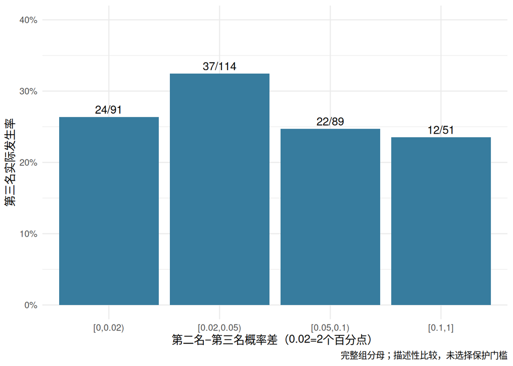

```r
strata |> filter(dimension == "gap23_band") |>
  ggplot(aes(stratum, rank3_rate)) + geom_col(fill = "#377c9e") +
  geom_text(aes(label = paste0(rank3_hits, "/", n)), vjust = -.4) +
  scale_y_continuous(labels = scales::percent, limits = c(0, .4)) +
  labs(x = "第二名−第三名概率差（0.02=2个百分点）", y = "第三名实际发生率",
    caption = "完整组分母；描述性比较，未选择保护门槛") + theme_minimal()
```

平均p3=24.50%，实际27.54%，平均低估约3.03个百分点。95场中86场的p3至少20%，仅9场在10%—20%，低于10%的共5场、没有发生。**绝大部分第三名并非模型认为极不可能的结果。**

第二／第三差距不足2个百分点91场，第三名发生24场（26.4%）；差2—5个百分点114场，发生37场（32.5%）；差5—10个百分点89场，发生22场（24.7%）；差至少10个百分点51场，发生12场（23.5%）。没有单调关系，不支持简单“只保护最接近第二名的第三名”。差不足5个百分点的205场贡献61次漏保，也包含大量未漏保场次。

## 来源与赛事：Top1差异不等于Top2差异

原生117场第三名发生32次（27.4%），市场来源228场63次（27.6%），几乎相同；此前原生Top1较差，并不能直接推出它更容易出现Top3。因此研究保护时应看Top2漏保，与主选命中分开。

联赛59/193（30.6%）、国家队27/84（32.1%）、杯赛4/25（16.0%）、青年5/43（11.6%）。这些比例受三期赛事构成、来源路由、让球分布影响；不代表长期赛事风险排序。具体联赛全部列出，不只挑最差者；小于10场的单联赛不能据此制定规则。

```r
knitr::kable(read_csv(file.path(out, "source_type.csv"), show_col_types = FALSE), digits = 4,
  caption = "赛事×来源联合分母：检查来源与赛事构成混杂")
```

赛事×来源联合分母：检查来源与赛事构成混杂

| event_type | selected_source | n | rank3_hits | rank3_rate | mean_p3 |
| --- | --- | --- | --- | --- | --- |
| cup | market | 16 | 3 | 0.1875 | 0.2479 |
| cup | native | 9 | 1 | 0.1111 | 0.1795 |
| league | market | 98 | 30 | 0.3061 | 0.2563 |
| league | native | 95 | 29 | 0.3053 | 0.2437 |
| national | market | 75 | 25 | 0.3333 | 0.2520 |
| national | native | 9 | 2 | 0.2222 | 0.1845 |
| youth | market | 39 | 5 | 0.1282 | 0.2399 |
| youth | native | 4 | 0 | 0.0000 | 0.1926 |

```r
knitr::kable(strata |> filter(dimension == "league"), digits = 4,
  caption = "所有来源赛事，含稀疏和零发生；探索性，不构成联赛黑名单")
```

所有来源赛事，含稀疏和零发生；探索性，不构成联赛黑名单

| dimension | stratum | n | rank3_hits | rank3_rate | mean_p3 | calibration_gap | share_of_95 |
| --- | --- | --- | --- | --- | --- | --- | --- |
| league | 中北美国联 | 1 | 0 | 0.0000 | 0.2302 | -0.2302 | 0.0000 |
| league | 亚运女足 | 4 | 1 | 0.2500 | 0.1639 | 0.0861 | 0.0105 |
| league | 亚运男足 | 6 | 0 | 0.0000 | 0.2325 | -0.2325 | 0.0000 |
| league | 国际友谊 | 11 | 4 | 0.3636 | 0.2390 | 0.1247 | 0.0421 |
| league | 墨西联 | 8 | 6 | 0.7500 | 0.2583 | 0.4917 | 0.0632 |
| league | 巴西乙 | 26 | 8 | 0.3077 | 0.2480 | 0.0597 | 0.0842 |
| league | 巴西甲 | 11 | 5 | 0.4545 | 0.2646 | 0.1899 | 0.0526 |
| league | 挪威杯 | 1 | 0 | 0.0000 | 0.2410 | -0.2410 | 0.0000 |
| league | 挪甲 | 7 | 2 | 0.2857 | 0.1919 | 0.0938 | 0.0211 |
| league | 日职乙 | 20 | 3 | 0.1500 | 0.2685 | -0.1185 | 0.0316 |
| league | 日联杯 | 7 | 0 | 0.0000 | 0.1507 | -0.1507 | 0.0000 |
| league | 欧国联 | 68 | 22 | 0.3235 | 0.2507 | 0.0728 | 0.2316 |
| league | 欧青U21外 | 37 | 5 | 0.1351 | 0.2360 | -0.1008 | 0.0526 |
| league | 爱甲 | 8 | 4 | 0.5000 | 0.2633 | 0.2367 | 0.0421 |
| league | 爱超 | 3 | 1 | 0.3333 | 0.2577 | 0.0756 | 0.0105 |
| league | 罗甲 | 1 | 1 | 1.0000 | 0.2198 | 0.7802 | 0.0105 |
| league | 美职业 | 17 | 3 | 0.1765 | 0.2528 | -0.0763 | 0.0316 |
| league | 芬甲 | 5 | 1 | 0.2000 | 0.1927 | 0.0073 | 0.0105 |
| league | 芬超 | 3 | 0 | 0.0000 | 0.2074 | -0.2074 | 0.0000 |
| league | 苏冠 | 7 | 1 | 0.1429 | 0.2424 | -0.0996 | 0.0105 |
| league | 英乙 | 18 | 7 | 0.3889 | 0.2657 | 0.1232 | 0.0737 |
| league | 英甲 | 7 | 2 | 0.2857 | 0.2497 | 0.0360 | 0.0211 |
| league | 英锦赛 | 15 | 3 | 0.2000 | 0.2502 | -0.0502 | 0.0316 |
| league | 荷乙 | 14 | 5 | 0.3571 | 0.2403 | 0.1168 | 0.0526 |
| league | 葡甲 | 1 | 0 | 0.0000 | 0.3150 | -0.3150 | 0.0000 |
| league | 西乙 | 22 | 6 | 0.2727 | 0.2552 | 0.0176 | 0.0632 |
| league | 阿根廷杯 | 2 | 1 | 0.5000 | 0.2665 | 0.2335 | 0.0105 |
| league | 阿甲 | 14 | 4 | 0.2857 | 0.2371 | 0.0486 | 0.0421 |
| league | 韩K联 | 1 | 0 | 0.0000 | 0.3033 | -0.3033 | 0.0000 |

## 尾部是否制造第三名

```r
knitr::kable(transitions, caption = "实际赛果从尾部前排名到最终排名的完整转移")
```

实际赛果从尾部前排名到最终排名的完整转移

| before_actual_rank | actual_rank | n |
| --- | --- | --- |
| 1 | 1 | 126 |
| 1 | 2 | 3 |
| 2 | 1 | 2 |
| 2 | 2 | 100 |
| 2 | 3 | 13 |
| 3 | 1 | 3 |
| 3 | 2 | 16 |
| 3 | 3 | 82 |

```r
knitr::kable(strata |> filter(dimension %in% c("actual_margin_in_core", "model_direction_reversed", "market_evidence")),
  digits = 4, caption = "实际核心／反向为事后描述；冻结盘口证据为历史赛前代理")
```

实际核心／反向为事后描述；冻结盘口证据为历史赛前代理

| dimension | stratum | n | rank3_hits | rank3_rate | mean_p3 | calibration_gap | share_of_95 |
| --- | --- | --- | --- | --- | --- | --- | --- |
| market_evidence | no_frozen_quote_rows | 64 | 18 | 0.2812 | 0.2327 | 0.0486 | 0.1895 |
| market_evidence | partial_or_not_admitted | 53 | 14 | 0.2642 | 0.2322 | 0.0320 | 0.1474 |
| market_evidence | sufficient_consistent | 228 | 63 | 0.2763 | 0.2515 | 0.0248 | 0.6632 |
| model_direction_reversed | FALSE | 266 | 60 | 0.2256 | NA | NA | 0.6316 |
| model_direction_reversed | TRUE | 79 | 35 | 0.4430 | NA | NA | 0.3684 |
| actual_margin_in_core | FALSE | 29 | 7 | 0.2414 | NA | NA | 0.0737 |
| actual_margin_in_core | TRUE | 316 | 88 | 0.2785 | NA | NA | 0.9263 |

尾部前第三名实际发生101场，最终95场。82场始终第三，13场由第二掉到第三，19场由第三抬入前二，净减少6场漏保。没有由第一直接掉第三。**尾部不是多数漏保的起点，但13场局部负贡献必须保留。**

95场中88场的实际净胜球仍在累计90%核心内，仅7场在外围；这证明“第三赛果”与“被压缩的净胜球尾部”是两个概念，不能把95场统称极端尾部风险。核心成员由比分分布定义，投影后的北单类别仍可能排第三。

## 市场能否识别这些第三名

```r
knitr::kable(market_cross, caption = "FM实际排名×北单实际排名；同截止与较晚SP分开")
```

FM实际排名×北单实际排名；同截止与较晚SP分开

| comparison | actual_rank | bd_rank | n |
| --- | --- | --- | --- |
| near_sale | 1 | 1 | 98 |
| near_sale | 1 | 2 | 22 |
| near_sale | 1 | 3 | 11 |
| near_sale | 2 | 1 | 25 |
| near_sale | 2 | 2 | 60 |
| near_sale | 2 | 3 | 34 |
| near_sale | 3 | 1 | 7 |
| near_sale | 3 | 2 | 32 |
| near_sale | 3 | 3 | 56 |
| same_cutoff | 1 | 1 | 46 |
| same_cutoff | 1 | 2 | 27 |
| same_cutoff | 1 | 3 | 8 |
| same_cutoff | 2 | 1 | 15 |
| same_cutoff | 2 | 2 | 28 |
| same_cutoff | 2 | 3 | 26 |
| same_cutoff | 3 | 1 | 10 |
| same_cutoff | 3 | 2 | 23 |
| same_cutoff | 3 | 3 | 31 |

```r
knitr::kable(signals, digits = 4,
  caption = "历史报价Top1是否等于FM第三名：使用完整准入组分母，不只挑已发生场次")
```

历史报价Top1是否等于FM第三名：使用完整准入组分母，不只挑已发生场次

| comparison | bd_top1_is_fm_third | n | rank3_hits | rank3_rate | mean_fm_p3 | mean_bd_probability |
| --- | --- | --- | --- | --- | --- | --- |
| near_sale | FALSE | 308 | 88 | 0.2857 | 0.2457 | 0.2555 |
| near_sale | TRUE | 37 | 7 | 0.1892 | 0.2391 | 0.4162 |
| same_cutoff | FALSE | 171 | 54 | 0.3158 | 0.2492 | 0.2157 |
| same_cutoff | TRUE | 43 | 10 | 0.2326 | 0.2615 | 0.4151 |

95场FM漏保中，较晚北单也排第三56场，排第二32场，排第一仅7场。这说明简单改用北单Top1只能覆盖少部分这批漏保，不能据此保证套利。同截止有64场FM漏保可比较，其中北单排第一10场、第二23场、第三31场；另外31场FM漏保无同截止报价（整个345场有131场缺失），不能混用分母或补造报价。

signals表进一步按报价本身的分歧定义分组：北单Top1是否为FM第三名，不使用实际赛果划分。较晚报价含更多信息，仅作诊断，不能搬回T−24h决策；同截止分歧也未在独立新期验证，不能据此优化保护掩码。

## 代表场景（事后例证）

为避免只报一个最差案例，按每个实际场景取p3最小的一场（固定、事后展示规则），不把它当独立证据。完整95场可由fixtures.csv的rank3_hit筛得，原始完整分母保留。

```r
knitr::kable(cases |> select(fixture_id, league, home, away, handicap, score, ranked_order,
  probability_1, probability_2, p3, before_actual_rank, goal_difference_case,
  selected_source, near_sale_bd_actual_rank), digits = 4,
  caption = "W/D/L均为北单让球类别；非普通胜平负，除非h=0")
```

W/D/L均为北单让球类别；非普通胜平负，除非h=0

| fixture_id | league | home | away | handicap | score | ranked_order | probability_1 | probability_2 | p3 | before_actual_rank | goal_difference_case | selected_source | near_sale_bd_actual_rank |
| --- | --- | --- | --- | --- | --- | --- | --- | --- | --- | --- | --- | --- | --- |
| 26101:98 | 日职乙 | 八户云罗里 | 横滨FC | 1 | 0-2 | W>D>L | 0.6310 | 0.2259 | 0.1431 | 3 | giving_side_win_above_handicap | native | 1 |
| 26101:81 | 挪甲 | 赫德 | 奥德 | 1 | 2-3 | W>L>D | 0.5948 | 0.2192 | 0.1860 | 3 | giving_side_win_exact_handicap | native | 2 |
| 26101:91 | 荷乙 | 邓伯什 | 多德雷赫特 | 0 | 1-1 | W>L>D | 0.5196 | 0.2446 | 0.2358 | 3 | zero_handicap_actual_draw | market | 3 |
| 26102:60 | 欧国联 | 苏格兰 | 斯洛文 | 0 | 1-2 | W>D>L | 0.5444 | 0.3030 | 0.1526 | 3 | zero_handicap_away_win | market | 3 |
| 26102:54 | 欧国联 | 白俄罗 | 芬兰 | 0 | 1-0 | L>D>W | 0.4817 | 0.3066 | 0.2117 | 3 | zero_handicap_home_win | market | 3 |

例如26101#81赫德—奥德，主+1、实际2–3，实际让平排第三（18.60%），尾部前已第三；属于“让球方刚好赢到让球数”。26101#98八户云罗里—横滨FC，主+1、实际0–2，FM让负第三（14.31%），较晚北单却排第一，是确有市场分歧的例子。26102#60苏格兰—斯洛文，零让球、实际1–2，客胜第三（15.26%），较晚北单也排第三，是双方共同漏保，不能只归因于未用盘口。

## 可用结论与边界

优先研究“让平质量与零让球方向”的识别，而不是默认第三名等于弱方爆冷；保护组需要比较第三名与被换掉的第二名，不能只看p3绝对大小。当前gap23和p3没有给出简单、单调的事前识别规律，因此本轮不新增三选／切换阈值、不指定推荐保护场、不计算串关收益。

已知赛果历史诊断、三期样本、定性缺口和来源时间代理不变；赛后场景有标签依赖，不能用于训练前瞻规则。比分口径未全部独立核实为90分钟。假设家族为本报告15个预设维度及两个时点市场分歧，未做显著性检验或多重比较挑选；若以后变为下注规则，必须在截止前共享temporal_learning历史窗口学习并冻结，独立新期检验。

## 验证、重放和审查

客户端无新项目函数或新增依赖。`tests/testthat/test-fm17-rank3-scenes-20261016.R`覆盖全部345／95、每维分母、54让平／37正好到线、尾部82／13／19、同截止缺失、北单分歧概率、哈希JSON往返、修改冻结输入拒绝且不写输出。使用R4.6.1与既有tidyverse，Rscript入口为`r/fm17_rank3_scenes.R ROOT OUTPUT`；依赖版本记录receipt。未运行存在已记录旧客户端漂移的全仓tests/testthat.R，不声称全仓通过。无新Rcpp／包代码，不重复包安装。

```r
if (isTRUE(params$acceptance_required)) {
  acceptance <- jsonlite::fromJSON(file.path(out, "acceptance.json"), simplifyVector = FALSE)
  stopifnot(acceptance$status == "ACCEPTED", acceptance$blocking_findings == 0L)
  for (file in acceptance$files) stopifnot(
    digest::digest(file = file.path(root, file$path), algo = "sha256") == file$sha256)
  knitr::kable(bind_rows(acceptance$checks), format = "html", escape = TRUE,
    caption = "实际本地检查、独立重放和Codex审查；绑定最终文件哈希")
} else cat("预览，尚非最终验收。\n")
```

实际本地检查、独立重放和Codex审查；绑定最终文件哈希

| check | command | result |
| --- | --- | --- |
| R client integration and tamper regression | Rscript -e testthat::test_file(tests/testthat/test-fm17-rank3-scenes-20261016.R,stop_on_failure=TRUE) | 67 assertions pass; zero failures/errors |
| Independent replay | Rscript r/fm17_rank3_scenes.R ROOT OUTPUT | Seven CSV outputs byte-identical; source and client identity equal |
| CSV profile scope | EDA capability_manifest.py inspect; tabular_profile.py --max-rows 100000 --missing-token NA | 1677 input rows fully scanned; no truncation; only aggregate redacted profile, no row values |
| Initial codex review | codex review scoped prompt; review.log | No blockers, 65 assertions independently rerun |
| Final codex review | codex review scoped prompt; review-final.log | No code blockers, 67 assertions independently rerun; final QMD gate render is next separate local check |
| Clean acceptance render | QUARTO_R=/opt/R/4.6.1/bin/R quarto render quarto/fm17_rank3_scenes_20261016.qmd --no-cache | 12 nonempty tables, one figure, no execution errors, SHA acceptance gate passed |

```r
knitr::kable(tibble(source = names(receipt$source_hashes), sha256 = unlist(receipt$source_hashes)),
  caption = "输入快照身份；输出哈希与原截止记录在receipt和fixtures")
```

输入快照身份；输出哈希与原截止记录在receipt和fixtures

| source | sha256 |
| --- | --- |
| fixtures | 687a6bcf5342b6338c9827334c4383fdf6599f2a7a7906e296a00e2f19737fd7 |
| forecast | e537428c0a43f966542c703d3edf6264722c95a7551dbabf7853aa909354e786 |
| labels | eb9cada49bd93eeed5df4592bb929a7ced1aeadcdf83d9971318f98388f8f89e |
| coverage | 678dc4d670e3befc804e247cfc7b74fe0af8741b1fa58bdf8541b62495add593 |
| sp | f29da4a474382b78912635c9ee53790bd33c7064a0dbbed1491cc3ce3c3ea1da |